# Analyzing single-cell bisulfite sequencing data with vmrseq

Ning Shen

Department of Statistics, University of British Columbia;Centre for Molecular Medicine and Therapeutics, BC Children’s Hospital Research Institute  
ning.shen@stat.ubc.ca

# Citation

**If you use vmrseq in published research, please cite:**

Shen, Ning, and Keegan Korthauer. “vmrseq: Probabilistic Modeling of Single-Cell Methylation Heterogeneity.” bioRxiv, November 21, 2023. https://doi.org/10.1101/2023.11.20.567911.

# Installation

This package will be submitted to Bioconductor. For now, you can install the development version from our [GitHub repository](https://github.com/nshen7/vmrseq) through running this:

```r
# install.packages("devtools")
devtools::install_github("nshen7/vmrseq")
```

After installation, load the vmrseq package:

```r
library(vmrseq)
```

How to get help for vmrseq: Feel free to raise questions by opening issue(s) in the [vmrseq GitHub repository](https://github.com/nshen7/vmrseq)

# Background

High-throughput single-cell measurements of DNA methylation allows studying inter-cellular epigenetic heterogeneity, but this task faces the challenges of sparsity and noise. We present `vmrseq`, a statistical method that overcomes these challenges to accurately and robustly identify de novo variably methylated regions (VMR) in single-cell DNA methylation data. To the best of our knowledge, vmrseq has been the only method that flexibly pinpoints biologically relevant regions at single-base pair resolution without prior knowledge of size or location. In addition, vmrseq is the only approach capable of detecting VMRs that are sensitive to the level of heterogeneity present in input datasets so far.

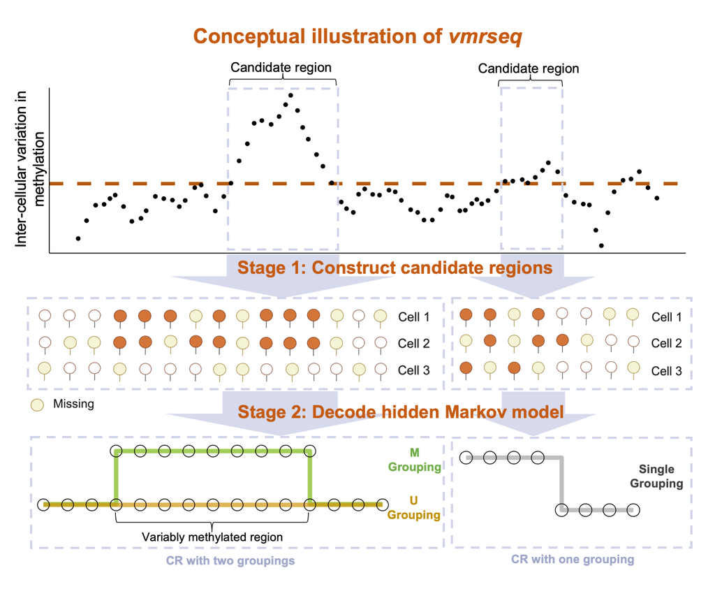

# Input data

vmrseq takes processed and filtered single-cell bisulfite sequencing **binary** methylation values as input. After processing and filtering, each sequenced CpG takes a value of methylated or unmethylated in each cell.

## On the note of pre-processing

In the experiments of the vmrseq manuscript, the authors did not carry out the pre-processing but instead, adopted the processed .bam files provided by the original publications of the sequencing protocol and datasets. However, by summarizing the processing steps described in those publications as sources, we offer a flexible guideline intended to serve as a general reference rather than a strict requirement:

1. Remove cells with a low non-conversion rate (e.g., $\leq1\%$ in mouse and $\leq2\%$ in human).
2. To eliminate contaminated samples, remove cells with a low number of non-clonal mapped reads (e.g., 400K in mouse; 500K in human).
3. To protect against wells with multiple cells, remove cells exceeding an upper limit on coverage ($\leq15\%$ of cytosines).
4. Remove cells with low CpG site coverage (e.g., $\leq50,000$ CpG sites)

## Process and filter individual-cell read files

We have implemented a `data.pool` function to process individual-cell read files into a format that is suitable to input to the vmrseq framework. Following is an example of how to use this function.

The `data.pool` function pools individual-cell CpG read files into a SummarizedExperiment object (with *NA-dropped sparseMatrix representation* by default). Store the file paths of individual cells to a list, for example, called `cell_list`, and input it to `data.pool` function. `data.pool` does not give any output but directly writes the SummarizedExperiment object into the `writeDir` specified by the user, here is an example: (this step might take long in practice since input datasets usually contain many cells; suggest to parallelize the computation with chromosomes)

```r
data.pool(cellFiles = cell_list, sep = ",", chrNames = "chr1", writeDir = "your/write/path")
```

Note that in each cell, sites with hemimethylation or intermediate methylation levels (i.e., 0 < meth_read/total_read < 1) will be removed.

Each cell file should be in BED-like format, where the first 5 columns in each file must be: *chr*, *pos*, *strand*, *meth_read*, *total_read*, in strict order, for example:

```r
data("cell_1")
head(cell_1)
```

```
##     V1      V2 V3 V4 V5
## 1 chr1 3012096  *  2  2
## 2 chr1 3020332  *  1  1
## 3 chr1 3021720  *  1  1
## 4 chr1 3027398  *  3  3
## 5 chr1 3029094  *  1  1
## 6 chr1 3029105  *  1  1
```

The `SummarizedExperiment` object stores CpG sites as rows and cells as columns. We adopted the NA-dropped sparseMatrix representation to save storage space for large single-cell datasets (see following section for specifics of how this representation look like). This option can be turned off but we recommend to keep it on.

Further, `data.pool` saves the `SummarizedExperiment` object into disk using `HDF5` format, which is a backend extension of `DelayedArray`. The HDF5/DelayedArray format allows one to perform common array operations on it without loading the object in memory. See packages [HDF5Array](https://bioconductor.org/packages/release/bioc/html/HDF5Array.html) and [DelayedArray](https://bioconductor.org/packages/release/bioc/html/DelayedArray.html) for details.

## Load example data

In this vignette, we use a formatted example dataset built in the package that’s ready to be input to model fitting function (which is not accessible to users due to format limitation of internal data of R packages). In usual cases users of this package would use `HDF5::loadHDF5SummarizedExperiment` to load saved HDF5SummarizedExperiment objects into R.

```r
toy.se <- HDF5Array::loadHDF5SummarizedExperiment(system.file("extdata", "toy", package = "vmrseq"))
```

It is a `SummarizedExperiment` object with one `assay` slot called `M_mat` that contains the binary methylation values of individual cells at CpG sites (sites as rows and cells as columns):

```r
toy.se
## class: RangedSummarizedExperiment
## dim: 30000 200
## metadata(0):
## assays(1): M_mat
## rownames: NULL
## rowData names(0):
## colnames(200): V1 V1 ... V1 V1
## colData names(0):
```

```r
dim(toy.se)
```

```
## [1] 30000   200
```

```r
GenomicRanges::granges(toy.se)
## GRanges object with 30000 ranges and 0 metadata columns:
##           seqnames    ranges strand
##              <Rle> <IRanges>  <Rle>
##       [1]   pseudo   3000827      *
##       [2]   pseudo   3001007      *
##       [3]   pseudo   3001018      *
##       [4]   pseudo   3001277      *
##       [5]   pseudo   3001629      *
##       ...      ...       ...    ...
##   [29996]   pseudo   8523533      *
##   [29997]   pseudo   8523719      *
##   [29998]   pseudo   8523783      *
##   [29999]   pseudo   8523864      *
##   [30000]   pseudo   8524231      *
##   -------
##   seqinfo: 1 sequence from an unspecified genome; no seqlengths
```

```r
SummarizedExperiment::assays(toy.se)
```

```
## List of length 1
## names(1): M_mat
```

Moreover, the assay matrix is in *NA-dropped sparseMatrix representation* (implemented using the `recommenderlab::dropNA` function):

```r
SummarizedExperiment::assays(toy.se)$M_mat[5:10, 5:10]
## <6 x 6> sparse DelayedMatrix object of type "double":
##                 V1            V1            V1            V1            V1
## [1,]  0.000000e+00  0.000000e+00  0.000000e+00  0.000000e+00  0.000000e+00
## [2,]  0.000000e+00  0.000000e+00  0.000000e+00  0.000000e+00  0.000000e+00
## [3,]  0.000000e+00  0.000000e+00  0.000000e+00  0.000000e+00  0.000000e+00
## [4,]  0.000000e+00  0.000000e+00  0.000000e+00  0.000000e+00  0.000000e+00
## [5,]  0.000000e+00  0.000000e+00  1.000000e+00  0.000000e+00  0.000000e+00
## [6,]  0.000000e+00  0.000000e+00  0.000000e+00  0.000000e+00  0.000000e+00
##                 V1
## [1,]  0.000000e+00
## [2,]  0.000000e+00
## [3,]  0.000000e+00
## [4,]  0.000000e+00
## [5,]  0.000000e+00
## [6,] 2.225074e-308
```

In particular, the NAs in the dataset are represented by 0 (or 0.000000e+00 as shown above), and the 0’s are represented in a very small positive real number (2.225074e-308 as shown above). This allows the matrix to be stored in a `sparseMatrix` format so that it takes less disk storage. One can use the `vmrseq::HDF5NAdrop2matrix` function to convert the assay from HDF5SummarizedExpriment object saved by `vmrseq::data.pool` back to regular matrices.